# ¶ “La realidad académica en las universidades Universidad de Ingeniería y Tecnología (UTEC) y Universidad Mayor de San Marcos (UNMSM)” ¶

## Relevancia del tema:

El análisis de las realidades de estas dos universidades nos brinda datos de relevancia ya que nos proporciona información que ayudarán a las instituciones o entes en materia educativa a tomar desiciones informadas y gestionar acciones estructurales. El tener un análisis estadístico de un panorama integral proporciona información para el desarrollo institucional y mejora continua de ambas instituciones. La identificación de las áreas donde cada universidad destaca y las oportunidades de mejora, permitirá implementar estrategias efectivas para optimizar la calidad en la educación superior.

### Objetivos:

- Determinar si existe una diferencia en la realidad académica entre una universidad pública(UNMSM) y privada(UTEC).
- Evaluar los recursos que se han destinado para fomentar la inclusión sin distinción de raza, género en los estudiantes en las universidades y cómo han sido utilizados.
- Analizar los factores que pueden estar afectando el acceso y permanencia de los estudiantes en la educación superior.
- Determinar las diferencias entre estudiantes de la universidad pública(UNMS) y privada(utec).

## Datos

### Proceso de Recoleccion de datos:

- Se obtuvo los datos a través de la técnica de muestreo por encuestas en Google Forms. Para ello, se realizó una serie de preguntas, cuyas respuestas permiten ser clasificadas en varios tipos de variables para un mejor análisis del problema.

## Variables:

- Total : 29 variables
- 16 categóricas
- 9 numéricas

### Variables más relvantes:

- Universidad
- Promedio
- Nivel de satisfacción con la universidad
- Nivel de estrés

### Limpieza de datos:

- Cambio de nombre de las variables, pues los nombres eran largos.
- Eliminamos columnas que no brindaban datos, como el correo.
- Eliminación de datos atípicos que sobrepasaban el límite.
- Cambio de nombre de universidades por su abreviatura.

## **Analisis descriptivo**

### Objetivo 1:

- Determinar si existe una diferencia en la realidad académica entre una universidad pública(UNMSM) y privada(UTEC).

### Gráfico 1:

- Comparativa entre los promedios de los alumnos de ambas universidades(UTEC y UNMSM)

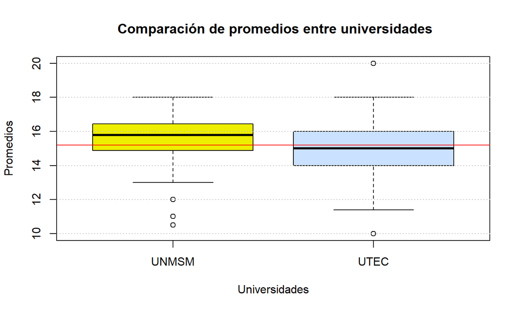

## **Analisis descriptivo**

### Objetivo 2:

- Evaluar los recursos que se han destinado para fomentar la inclusión sin distinción de raza, género en los estudiantes en las universidades y cómo han sido utilizados.

- Muestra la presencia o ausencia de estudiantes con beca en cada universidad (UTEC - UNMSM)

```
     UNMSM UTEC
  No    66   55
  Sí     9   68
```

```
     UNMSM  UTEC
  No 88.00 44.72
  Sí 12.00 55.28
```

## **Analisis descriptivo**

### Objetivo 3:

- Analizar los factores que pueden estar afectando el acceso y permanencia de los estudiantes en la educación superior.

### Gráfico 3:

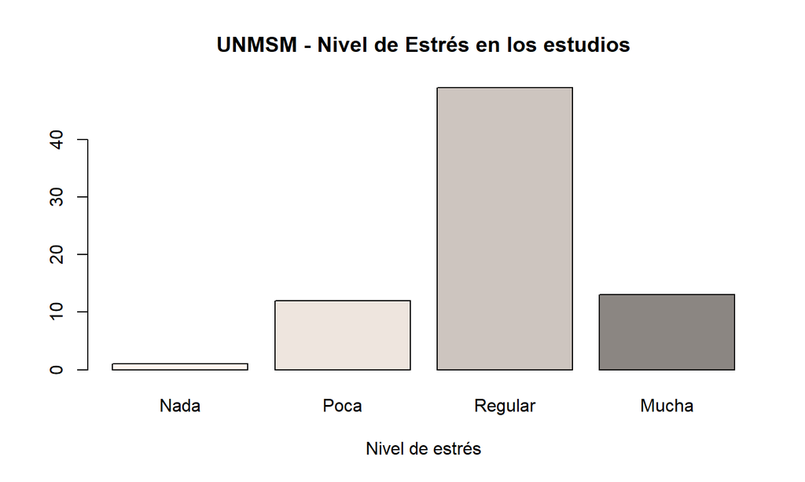

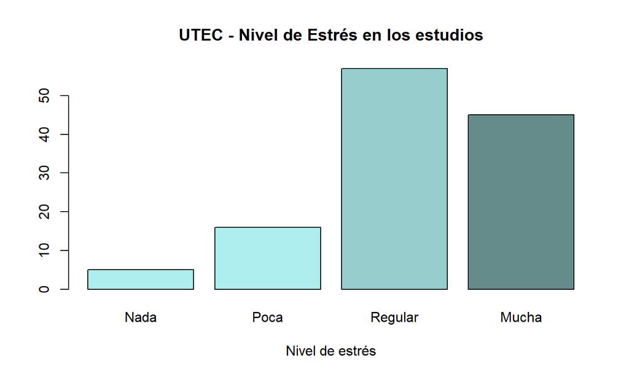

## **Analisis descriptivo**

### Objetivo 4:

- Determinar las diferencias entre estudiantes de la universidad pública y privada(utec).

### Gráfico 4:

- Clases sociales de los estudiantes en las universidades de UTEC y UNMSM

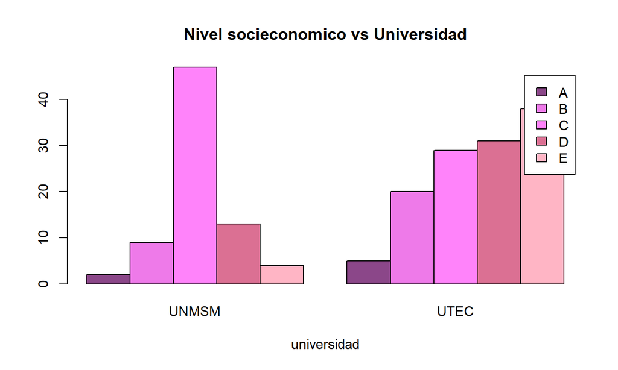

## **Analisis probabilístico**

### *Probabilidad empírica*

- Variable escogida: Promedio

Tabla de probabilidad en los rangos del promedio

```
          UNMSM UTEC Sum
  [10,11]     2    1   3
  (11,12]     3    7  10
  (12,13]     4    9  13
  (13,14]     5   23  28
  (14,15]    19   29  48
  (15,16]    15   25  40
  (16,17]    16   19  35
  (17,18]    11    7  18
  (18,19]     0    0   0
  (19,20]     0    3   3
  Sum        75  123 198
```

```
        UNMSM UTEC  UNMSM   UTEC
[10,11]     2    1 0.0101 0.0051
(11,12]     3    7 0.0152 0.0354
(12,13]     4    9 0.0202 0.0455
(13,14]     5   23 0.0253 0.1162
(14,15]    19   29 0.0960 0.1465
(15,16]    15   25 0.0758 0.1263
(16,17]    16   19 0.0808 0.0960
(17,18]    11    7 0.0556 0.0354
(18,19]     0    0 0.0000 0.0000
(19,20]     0    3 0.0000 0.0152
```

```r
197*11
```

```
[1] 2167
```

Objetivos:

**Determinar que tan probable que un estudiante de UTEC tengan un promedio en el rango de 19 a 20.**

```
[1] "P(J) = 3/197"
```

```
[1] 0.01522843
```

**Determinar que tan probable que un estudiante de UNMSM tengan un promedio en el rango de 19 a 20**

```
[1] "P(J) = 0/197"
```

```
[1] 0
```

No existe la probabilidad de que un alumno de la UNMSM tenga un promedio en el rango de 19 a 20

- Variable escogida: Satisfacción

```
                UNMSM UTEC Sum
  1 (muy mala)      1    2   3
  2 (mala)          2    2   4
  3 (regular)      22   19  41
  4 (buena)        42   67 109
  5 (muy buena)     8   33  41
  Sum              75  123 198
```

```
              UNMSM UTEC  UNMSM   UTEC
1 (muy mala)      1    2 0.0051 0.0101
2 (mala)          2    2 0.0101 0.0101
3 (regular)      22   19 0.1111 0.0960
4 (buena)        42   67 0.2121 0.3384
5 (muy buena)     8   33 0.0404 0.1667
```

```r
197*5
```

```
[1] 985
```

Objetivos:

**Determinar que tan probable que un estudiante de UTEC sienta una satisfacción muy alta(5) con su universidad.**

```
[1] "P(E) = 33/197"
```

```
[1] 0.1675127
```

**Determinar que tan probable que un estudiante de UNSMS sienta una satisfacción muy alta(5) con su universidad.**

```
[1] "P(E) = 8/197"
```

```
[1] 0.04060914
```

## **Analisis probabilístico**

### *Probabilidad condicional*

- Eventos independientes:

Para comprobar que 2 eventos sean independientes, se debe cumplir que P(A ∩ B) = P(A)*P(B)

Para esto definimos los eventos:

E = Promedio entre 10 - 11

F = Promedio entre 11 - 12

G = Promedio entre 12 - 13

H = Promedio entre 13 - 14

I = Promedio entre 14 - 15

J = Promedio entre 15 - 16

K = Promedio entre 16 - 17

L = Promedio entre 17 - 18

N = Promedio entre 18 - 19

O = Promedioe ntre 19 - 20

T = UTEC

M = UNMSM

- OBJETIVO 2: Determinar las probabilidades de ocurrencia en los promedios por tipo de universidad, en el semestre 2023-1
- OBJETIVO 2.1. Determinar la probabilidad de tener un promedio 16-17 dado que es de UTEC

P(K ∩ T) = P(K)*P(T)

P(K ∩ T) = 0.0964 #Dato obtenido de las tablas

P(K) =

```r
0.0812 + 0.0964
```

```
## [1] 0.1776
```

P(T) =

```r
0.0051 + 0.0355+0.0457 +0.1168 + 0.1472+0.1269+0.0964+0.0355+0.0000+0.0152
```

```
## [1] 0.6243
```

P(K)*P(T) =

```r
0.1776 * 0.6243
```

```
## [1] 0.1108757
```

Se observa que P(K ∩ T) != P(K)*P(T), esto significa que no son eventos independientes.

- OBJETIVO 2.2. Determinar la probabilidad de tener un promedio 13-14 dado que es de UNMSM

P(H ∩ M) = P(H)*P(M)

P(H ∩ M) = 0.0254 #Dato obtenido de las tablas

P(H) =

```r
0.0254 + 0.1168
```

```
## [1] 0.1422
```

P(M) =

```r
0.0102 + 0.0152 + 0.0203 + 0.0254+0.0914+0.0761+0.0812+0.0558+0+0
```

```
## [1] 0.3756
```

P(H)*P(M) =

```r
0.1422 * 0.3756
```

```
## [1] 0.05341032
```

Se observa que P(H ∩ M) != P(H)*P(M), esto significa que no son eventos independientes.

En ambos casos, no se cumple la regla para comprobar que 2 eventos sean independientes. En otras palabras, la ocurrencia de estos eventos en la vida real es muy peculiar. Esto sucede porque hay muchos factores que rodean a los eventos: influencia mutua, dependencia temporal, influencia social, causas ocultas, etc.

**Eventos dependientes**

- Objetivo 2.3. Determinar la probabilidad de tener un promedio de 10-11 dado que es de UNMSM P(E/M) = P(E ∩ M)/P(M)

P(E ∩ M) = 0.0102 #Dato obtenido de tablas

P(M) =

```r
0.0102 + 0.0152 + 0.0203 + 0.0254+0.0914+0.0761+0.0812+0.0558+0+0
```

```
## [1] 0.3756
```

P(E/M)

```r
0.0102/0.3756
```

```
## [1] 0.02715655
```

- Objetivo 2.3.1 Determinar la probabilidad de tener un promedio de 10-11 dado que es de UTEC

P(E/T) = P(E ∩ T)/P(T)

P(E ∩ T) = 0.0051 #Dato obtenido de tablas

P(T) =

```r
0.0051 + 0.0355+0.0457 +0.1168 + 0.1472+0.1269+0.0964+0.0355+0.0000+0.0152
```

```
## [1] 0.6243
```

P(E/M)

```r
0.0051/0.6243
```

```
## [1] 0.008169149
```

Del cálculo probabilístico se obtiene que la probabilidad de que un estudiante de UNMSM tenga un promedio de [10-11] es 0.02715655, mientras que, para un estudiante de UTEC esta probabilidad es de 0.008169149. Esto vislumbra que es mas probable que un estudiante de UNMSM jale un curso, lo cual muestra las implicancias educativas en cada caso: cursos más complicados de entender, menos laboratorios, profesores no tan eficientes, etc.

## **Analisis probabilístico**

### *Variables aleatorias Discretas*

- Variable escogida: Satisfacción

Tabla de probabilidad de Satisfacción en el total de estudiantes

```
               fi    pi
1 (muy mala)    3  1.52
2 (mala)        4  2.02
3 (regular)    41 20.71
4 (buena)     109 55.05
5 (muy buena)  41 20.71
```

```
 1 (muy mala)      2 (mala)   3 (regular)     4 (buena) 5 (muy buena)
       0.0152        0.0202        0.2071        0.5505        0.2071
```

- Gráfica de la distribución geométrica negativa con la variable satisfacción.

```
Warning in dnbinom(valores, size = -2.98197857893356, prob =
0.479386385426654): NaNs produced
```

[figure not shown]

- Variable escogida: Nivel de estrés

```
          UNMSM UTEC Sum
  Mucha      13   45  58
  Nada        1    5   6
  Poca       12   16  28
  Regular    49   57 106
  Sum        75  123 198
```

```
        UNMSM UTEC  UNMSM   UTEC
Mucha      13   45 0.0657 0.2273
Nada        1    5 0.0051 0.0253
Poca       12   16 0.0606 0.0808
Regular    49   57 0.2475 0.2879
```

1. X ~ Hipergeométrica (N, r, n) donde X : número de estudiantes de UTEC que tienen mucho nivel de estres respecto a su universidad en 58 estudiantes encuestados de dos universidades(UTEC Y UNMSM) que tienen mucho nivel de estres respecto a su universidad

r = éxitos en la población: 45 estudiantes de UTEC que tienen mucho nivel de estres respecto a su universidad entre los 197 encuestados.

n = 58 estudiantes encuestados de dos universidades(UTEC Y UNMSM) que tienen mucho nivel de estres respecto a su universidad

N = Tamaño de la muestra: 197 estudiantes encuestados de dos universidades(UTEC Y UNMSM)

1. calculamos la densidad Sea X ~ H (N=197, r=45, n=58)

```
## [1] 1
```

[figure not shown]

```
## [1] 1
```

[figure not shown]

## **Analisis probabilístico**

### *Variables aleatorias Continuas*

Variable escogida: Promedio

- Promedio UTEC

Definimos la hipótesis: H0:La distribución de los promedios ponderado de los estudiantes en UTEC se aproxima a una distribución normal. H1:La distribución de los promedios ponderado de los estudiantes en UTEC es diferente a una distribución normal. Para ello necesitamos comprobar:

```
##                logL     AIC     BIC Chisq(value) Chisq(p) AD(value)
## Normal      -241.42  486.83  492.46       161.52        0      0.66
## Cauchy      -258.64  521.29  526.91       161.04        0      1.86
## Logistic     -240.5     485  490.62       149.55        0      0.57
## Exponential -456.33  914.66  917.47      2053.71        0     44.78
## Chi-square  -327.34  656.67  659.48       622.24        0     20.69
## Uniform        NULL    NULL    NULL       216.60        0       Inf
## Gamma        -241.3  486.61  492.23       159.78        0      0.67
## Lognormal   -241.74  487.49  493.11       159.81        0      0.74
## Weibull     -249.39  502.78  508.41       197.18        0      1.93
## F           -611.71 1227.43 1233.05      7588.80        0     69.95
## Student     -709.77 1421.54 1424.35     16991.33        0    124.65
##                    H(AD) KS(value)        H(KS)
## Normal      not rejected      0.09 not rejected
## Cauchy          rejected      0.09 not rejected
## Logistic    not rejected      0.09 not rejected
## Exponential     rejected      0.53     rejected
## Chi-square          NULL      0.30     rejected
## Uniform             NULL      0.11 not rejected
## Gamma       not rejected      0.10 not rejected
## Lognormal   not rejected      0.11 not rejected
## Weibull         rejected      0.10 not rejected
## F                   NULL      0.68     rejected
## Student             NULL      0.83     rejected
```

```
##
## Chosen continuous distribution is: NA
## Fitted parameters are:
## [1] NA
```

Después de Utilizar la fit.cont podemos decir:

AD(value)≥ α -> not rejected H0

0.66 ≥ 0.05 -> not rejected H0

KS(value)≥ α -> not rejected H0

0.09 ≥ 0.05 -> not rejected H0

- Promedio UNMSM

Definimos la hipótesis:

H0:La distribución de los promedios ponderado de los estudiantes en UNMSM se aproxima auna distribución Cauchy.

H1:La distribución de los promedios ponderado de los estudiantes en UNMSM es diferente auna distribución Cauchy.

Para ello necesitamos comprobar:

```
##                logL    AIC    BIC Chisq(value) Chisq(p) AD(value)        H(AD)
## Normal      -144.06 292.12 296.76        22.28        0      1.18     rejected
## Cauchy      -153.14 310.28 314.91        24.86        0      1.51 not rejected
## Logistic    -143.27 290.55 295.18        22.49        0      0.87     rejected
## Exponential  -280.4  562.8 565.12       579.52        0     27.76     rejected
## Chi-square  -200.53 403.06 405.38       149.21        0     13.39         NULL
## Uniform        NULL   NULL   NULL        36.86        0       Inf         NULL
## Gamma       -146.46 296.93 301.56        23.05        0      1.56     rejected
## Lognormal   -147.92 299.83 304.47        23.60        0      1.79     rejected
## Weibull     -140.43 284.85 289.49        23.16        0      0.74     rejected
## F           -375.95  755.9 760.53      2254.65        0     42.69         NULL
## Student     -435.63 873.26 875.57      5085.05        0     75.99         NULL
##             KS(value)        H(KS)
## Normal           0.12 not rejected
## Cauchy           0.14 not rejected
## Logistic         0.11 not rejected
## Exponential      0.51     rejected
## Chi-square       0.35     rejected
## Uniform          0.16     rejected
## Gamma            0.14 not rejected
## Lognormal        0.15 not rejected
## Weibull          0.10 not rejected
## F                0.68     rejected
## Student          0.83     rejected
```

```
##
## Chosen continuous distribution is: NA
## Fitted parameters are:
## [1] NA
```

Después de Utilizar la fit.cont podemos decir:

AD(value)≥ α -> not rejected H0

1.51 ≥ 0.05 -> not rejected H0

Variable escogida: Tiempo

Definimos la hipótesis:

H0:La distribución del tiempo que toma en llegar a la universidad los estudiantes de dos universidades(UNMSM y UTEC) se aproxima auna distribución exponecial.

H1:La distribución del tiempo que toma en llegar a la universidad los los estudiantes de dos universidades(UNMSM Y UTEC) es diferente auna distribución exponencial. Para ello necesitamos comprobar:

```
##                 logL     AIC     BIC Chisq(value) Chisq(p) AD(value)    H(AD)
## Normal      -1061.77 2127.54 2134.11 1.111800e+02        0      7.55 rejected
## Cauchy      -1089.48 2182.96 2189.54 1.249200e+02        0     13.65 rejected
## Logistic    -1063.16 2130.32  2136.9 1.030400e+02        0      6.71 rejected
## Exponential  -1001.5    2005 2008.29 2.984000e+01        0      1.56 rejected
## Chi-square  -3178.75  6359.5 6362.78 6.730585e+11        0       Inf     NULL
## Uniform         NULL    NULL    NULL 1.066600e+02        0       Inf     NULL
## Gamma       -1001.42 2006.84 2013.42 2.849000e+01        0      1.45       NA
## Lognormal   -1022.57 2049.15 2055.72 6.141000e+01        0      4.34 rejected
## Weibull      -1001.5    2007 2013.58 3.001000e+01        0      1.58 rejected
## F           -1183.78 2371.57 2378.14 4.881400e+02        0     60.51     NULL
## Student     -1333.23 2668.47 2671.75 1.242450e+03        0    158.34     NULL
## Gompertz     -999.69 2003.39 2009.96 3.177000e+01        0      2.15     NULL
##             KS(value)        H(KS)
## Normal           0.18     rejected
## Cauchy           0.22     rejected
## Logistic         0.15     rejected
## Exponential      0.09 not rejected
## Chi-square       0.43     rejected
## Uniform          0.18     rejected
## Gamma            0.09 not rejected
## Lognormal        0.12     rejected
## Weibull          0.09 not rejected
## F                0.45     rejected
## Student          0.66     rejected
## Gompertz         0.11     rejected
```

```
##
## Chosen continuous distribution is: NA
## Fitted parameters are:
## [1] NA
```

Después de Utilizar la fit.cont podemos decir:

KS(value)≥ α -> not rejected H0